# Assignment 8

Withee Poositasai

2022-12-06

# Introduction

We will take a look at the dataset of admitted students across different specialties recorded in 2021 from the Estonian statistics website. The dataset contain 108 rows and 6 columns showing how many students with each mother tongue are in each study level and program as following:

```
## Rows: 108
## Columns: 6
## $ `Level of study`        <chr> "Bachelor's study", "Bachelor's study", "Bache…
## $ `Study programme group` <chr> "Journalism and information", "Architecture an…
## $ Estonian                <dbl> 82, 31, 215, 173, 124, 571, 25, 266, 206, 67, …
## $ Russian                 <dbl> 3, 7, 45, 53, 24, 165, 0, 84, 40, 22, 0, 14, 1…
## $ `Other mother tongue`   <dbl> 0, 0, 1, 20, 5, 14, 0, 7, 8, 1, 0, 5, 1, 1, 0,…
## $ `Mother tongue unknown` <dbl> 0, 0, 0, 11, 9, 23, 0, 0, 23, 0, 0, 11, 0, 0, …
```

Level of study is a nominal categorical data (Because `Integrated Bachelor's/Master's study` is not clearly in order with other levels). The dataset include 4 levels including:

```
## [1] "Bachelor's study"
## [2] "Integrated Bachelor's/Master's study"
## [3] "Master's study"
## [4] "Doctoral study"
```

Then we have 27 study programme group as a nominal categorical data including:

```
##  [1] "Journalism and information"
##  [2] "Architecture and construction"
##  [3] "Biological and environmental sciences"
##  [4] "Physical sciences"
##  [5] "Humanities"
##  [6] "Information and Communication Technologies (ICTs)"
##  [7] "Personal services"
##  [8] "Languages and cultures"
##  [9] "Arts"
## [10] "Mathematics and statistics"
## [11] "Medicine"
## [12] "Music and performing arts"
## [13] "Psychology"
## [14] "Agriculture, forestry and fishery"
## [15] "Military and defence"
## [16] "Protection of persons and property"
## [17] "Social sciences"
## [18] "Social services"
## [19] "Sports"
## [20] "Engineering, manufacturing and technology"
## [21] "Health care"
## [22] "Transport services"
## [23] "Religion and theology"
## [24] "Veterinary"
## [25] "Law"
## [26] "Teacher training and education science"
## [27] "Business and administration"
```

Then we have Estonian, Russian, Other mother tongue, and Mother tongue unknown as a discrete numerical data representing number of student with each mother tongue.

# Research question

I want to test **if there is a relationship between level of study and student mother tongue** of admitted student in Estonia in 2021.

# EDA

Let have a look at the statistics of columns related to mother tongue languages.

```
##     Estonian         Russian       Other mother tongue Mother tongue unknown
##  Min.   :  0.00   Min.   :  0.00   Min.   :  0.000     Min.   : 0.000
##  1st Qu.:  0.00   1st Qu.:  0.00   1st Qu.:  0.000     1st Qu.: 0.000
##  Median : 12.50   Median :  1.00   Median :  0.000     Median : 0.000
##  Mean   : 66.64   Mean   : 12.57   Mean   :  7.231     Mean   : 6.583
##  3rd Qu.: 74.25   3rd Qu.: 13.00   3rd Qu.:  7.250     3rd Qu.: 4.000
##  Max.   :571.00   Max.   :165.00   Max.   :103.000     Max.   :88.000
```

Interestingly, Estonian and Russian having the 1st quadrant = 0 while other and unknown mother tongue having median = 0. This showing that a lot of record have value of 0 in these columns. So I plot the histogram of number of students with each mother tongue language to see the distribution. It is very skewed to the right as expected as shown below.

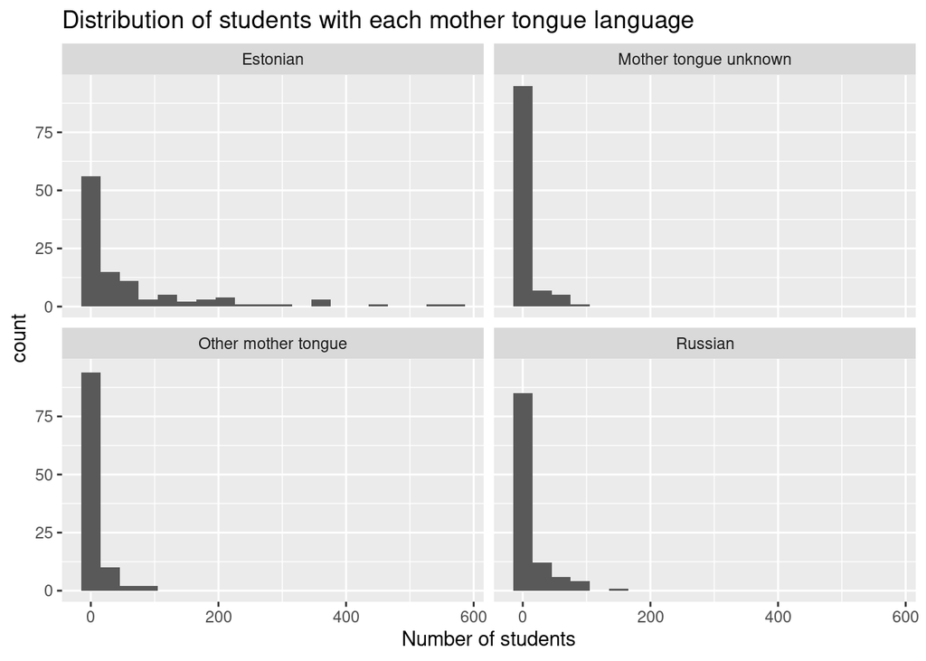

# Data cleaning and transformation

From the dataset, I want to

1. Remove `Study programme group` and `Mother tongue unknown` columns since it’s not related to the research question.
2. Remove *study* word in `Level of study` column because it is redundant.
3. Rename `Other mother tongue` column to `Other` to make it concise.
4. Pivot language related columns to long format of `Mother tongue language` and `Number of students`.
5. Change column data type
- `Level of study` and `Mother tongue language` to levels because it is a limit set of character.
- `Number of students` to integer because we don’t need decimal points.
6. Group data by the `Level of study` and `Mother tongue language`.

Here is the final result:

```
## # A tibble: 12 × 3
## # Groups:   Level of study, Mother tongue language [12]
##    `Level of study`               `Mother tongue language` `Number of students`
##    <fct>                          <fct>                                   <int>
##  1 Bachelor's                     Estonian                                 3705
##  2 Bachelor's                     Russian                                   806
##  3 Bachelor's                     Other                                     115
##  4 Master's                       Estonian                                 2804
##  5 Master's                       Russian                                   438
##  6 Master's                       Other                                     526
##  7 Integrated Bachelor's/Master's Estonian                                  519
##  8 Integrated Bachelor's/Master's Russian                                    91
##  9 Integrated Bachelor's/Master's Other                                      50
## 10 Doctoral                       Estonian                                  169
## 11 Doctoral                       Russian                                    23
## 12 Doctoral                       Other                                      90
```

Number of students for each mother tongue languages in each level of study can be show by the following chart:

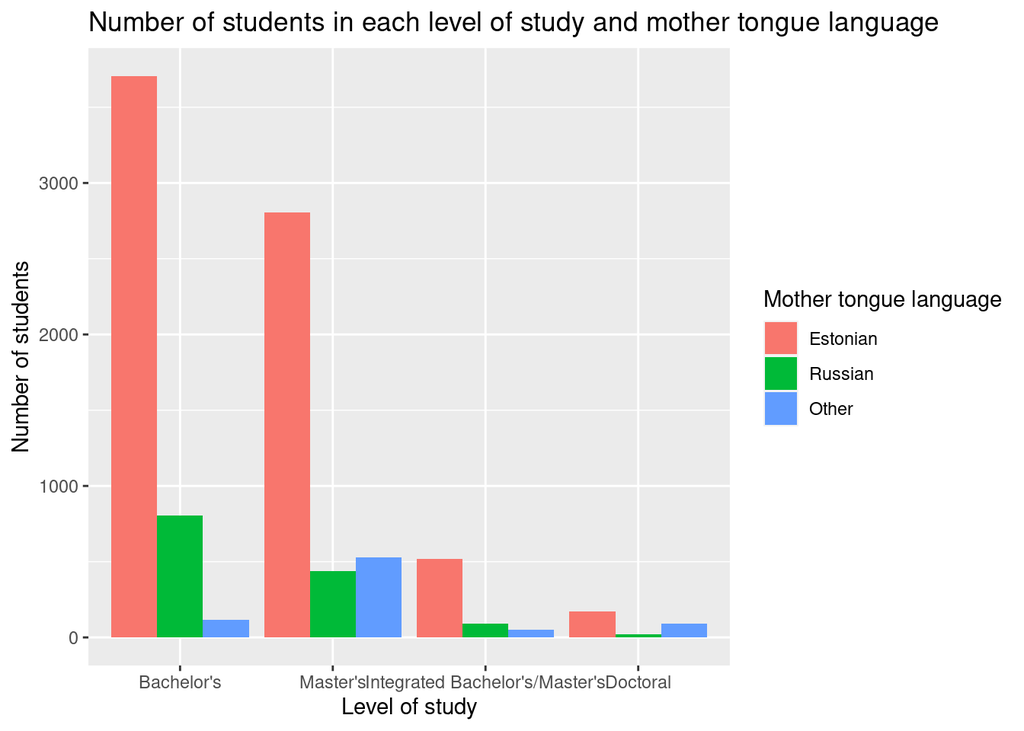

Estonian dominate in every study level as expected, but it is not clear to see if there is a relationship between level of study and mother tongue language.

# Hypothesis testing

- Null hypothesis: There is *no* relationship between level of study and student mother tongue language.
- Alternative hypothesis: There is a relationship between level of study and student mother tongue language.

Our sample size (number of total students) is

```
## [1] 9336
```

I want to test a relationship between study level and mother tongue language. Both variables are categorical thus Chi square test are appropriated. All of the assumption of Chi square are met as following:

First, I create a contingency table from the dataset.

```
##                                 Mother tongue language
## Level of study                   Estonian Russian Other
##   Bachelor's                         3705     806   115
##   Master's                           2804     438   526
##   Integrated Bachelor's/Master's      519      91    50
##   Doctoral                            169      23    90
```

No cell is less than 5, we should get an accurate result. So I run the Chi square test with confident interval of 99%.

```
##
##  Pearson's Chi-squared test
##
## data:  ctable
## X-squared = 596.06, df = 6, p-value < 2.2e-16
```

According to the [Chi square table](http://chisquaretable.net) with 0.01 probability and 6 degree of freedom, the critical value is 16.812. Chi square from the test is higher than the critical value and the p-value is very low so **we can reject the null hypothesis**.

# Conclusion

Chi square test show that **there is a relationship between level of study and student mother tongue language**. However we don’t know how much or what kind if relationship is that due to the limitation of Chi square test, and that could be the new research question for a further study.